# Sorting out the real situation in the Russo Ukrainian war

The purpose of this article is to provide a statistically based rebuttal with some commentary in response to some not fully informed views (of Ukraine supporters) and malicious attacks by some enemies of Ukraine independence.

## Changing Perceptions

In late February 2022, at the restart of this huge war, many, perhaps most, had a dismal view of Ukrainian prospects. The US leadership had a similar view as they offered Zelensky a personal rescue plan to which he iconically replied; ‘I don’t need a ride I need ammo’. The usual view was that the much larger Russia would overwhelm the Ukrainians.

From the start and for most of 2022, Western mainstream mass media was naturally intensely covering the daily events and the politically minded masses were also invested in the drama on their various social platforms. So from the very beginning, anyone who followed the war saw huge columns of Russian troops heading towards Kyiv, and other less prominent but significant urban targets of the invasion.

Within days however, Russian columns stalled in massive traffic jams and the commonly accepted ‘timetable’ to the predicted fall of Ukraine began to unravel.

Yet, despite the obvious signs of logistical bungling on the part of the Russians, it still appeared to the vast majority that Russia would eventually ‘win’ this war and reasonably quickly, only now by ‘eventually’ grinding down rather than quickly overwhelming the smaller Ukraine. The underlying thinking was now that ‘time was on Russia's side’.

When the Russians attacked, Ukrainians staged a fighting retreat until the initial Russian plans failed within days, most spectacularly with the stalled convoy near Kiev that had to be pulled out before it was totally lost. The wind back from the greatest extent of the Russian invasion was over the next month or so and a first class exposure of an incompetent gangster run army was revealed to those looking in the right direction.

## Not fully informed commentary

Just as importantly, information that is positive to Ukraine is neglected including from many American Democrats, even those who have supported Ukraine to some degree. For example, the Democrat Mark Kelly who recently toured Ukraine and strongly supports their cause hasn't revealed the information contained later in this article.

## Malicious attacks

Recently, US President Trump said "Zelensky has no cards". Trumps' prominent ally, Elon Musk, has said that Zelensky sends young people to die for no good reason, labelled Mark Kelly as a "traitor" and called the Polish foreign minister, Radoslaw Sikorski "a little man". The motivation of these two, who claim to be the correctors of fake news, remains unclear. Prior to the American election Trump and Musk made legitimate mileage in excoriating MSM on a host of issues but now when it comes to Ukraine they have openly joined the fake news purveyors.

This is the context in which I present the following corrective information, obtained from Patrick Muldowney who has studied this war deeply.

# Russian Personnel Casualties in Ukraine

Russia is losing this war. Russian casualties are amazingly high, now over 900,000 dead, injured, captured in the fourth year of the war. These figures come from *The Ministry of Defence of Ukraine. For the latest both daily and cumulative figures see [here](https://onedrive.live.com/edit?id=E33161B435D127BA!157482&resid=E33161B435D127BA!157482&ithint=file%2Cxlsx&authkey=!AHy27V-_Woq340I&wdo=2&cid=e33161b435d127ba).

```
[Text(0, 0, 'YEAR ONE'), Text(1, 0, 'YEAR TWO'), Text(2, 0, 'YEAR THREE')]
```

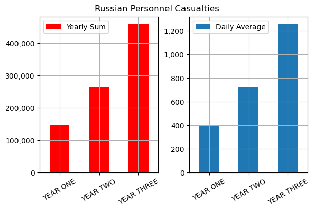

|  | YEAR | YEARLY SUM | DAILY AVERAGE |
| --- | --- | --- | --- |
|  | year 1 | 145,850 | 400 |
|  | year 2 | 262,390 | 719 |
|  | year 3 | 457,760 | 1,254 |

*Explanatory note about the graphs:* The large scale Russian invasion started on 24th Feb 2022. So, the yearly SUMS are the accumulated Russian casualties for each year starting on 24th February and finishing on the 23rd February of the next year (365 days).

*Are these figures reliable?* Go back to their [source](https://onedrive.live.com/edit?id=E33161B435D127BA!157482&resid=E33161B435D127BA!157482&ithint=file%2Cxlsx&authkey=!AHy27V-_Woq340I&wdo=2&cid=e33161b435d127ba). Some of the data there, eg. Warships / Boats & Aircraft categories, can be readily checked by outside observers. When considered from the change in use perspective alone they appears to be accurate. The Russians stopped using this equipment over or even close to the contact line. So, it is a small step to conclude that all of it is accurate. Not accurate down to the units column but in the real ball park. The trend lines which this data establishes create a more accurate narrative about what is going down.

The figures show that the Russian army is smashed. They have lost their invading army and don’t have the training capacity to rapidly reconstitute a comparable force. While it is correct that ‘quantity has a quality all of its own’, nevertheless the Russian military is, 37 months into this disaster, a shadow of what for many decades terrorised Europe. But it did so because it wasn’t used. In reality, it was riven with corruption and so was partially an apparition.

The Russians have lost their army. For example, they lost many of their quality troops when they tried to take Hostomel airport at the start of the war. Later on they were over run on Russian soil in Kursk. They’ve employed meat grinder, financially induced recruitment tactics and even sometimes using prisoners let out of gaol. Many of their troops are untrained. They have had to bring in North Koreans. Apparently the Koreans were lied to as to their mission and instead thrown in on the front line without having suitable methods to deal with the current realities and consequently they were slaughtered.

The Russians were even overrun on Russian soil in Kursk and suffered tremendous losses over the next 7 months trying to regain their own territory and have still not regained it all. In having to move capable troops to achieve this they have suffered fresh losses inside Ukraine itself. Ukraine still occupies a small part of Kursk and they have launched another incursion inside Russia at Belgrorod.

Ukrainian troops and youth are far more motivated than their Russian equivalents. This follows obviously from the former having a just cause and the latter an unjust cause. Many Russian youth of war fighting age have now fled the country.

Currently Russian troops are of very low morale and quality; that is to say poorly motivated. Often young or old, poorly trained they are reluctantly in an army with an inferior doctrine to that of current NATO standards with officers who are careless of their well being and more corrupt the higher the rank.

Of course, Ukraine as well as Russia is suffering from a manpower problem. But overall the Ukraine troops are superior quality to the Russians.

# Ukraine are masters of drone warfare

Ukrainian success to a large degree can be put down to their superiority with drone warfare.

The war has taken an unexpected breakthrough direction. It’s an artillery war and the new ‘artillery’ literally hunts you down! First Person View FPV, Unmanned Aerial Vehicles UAV’s, are the new artillery and these explosive charges are relentless and brutally effective.

This war is a drone war. And the Ukrainians are better at drone warfare (shown as *Unmanned Aerial Vehicles* or UAV on the graph) than the Russians. Drones come in various shapes and sizes: long, medium and short range; surveillance and attack.

Drone warfare is the new artillery. It takes out the tanks, armoured vehicles and much more. Drone warfare is a rapidly evolving technology and the Ukrainians are the masters at this warfare. The Russians are playing catchup. But they do learn and may even now have a lead in optic fibre drones.

Russia began this war with a huge advantage in artillery. Ukraine has overturned that advantage and now is demonstrating that it has the upper hand. Among other things drones are ‘tubeless’ artillery. Drones first replaced the forward artillery spotters, then the mortar bombing squads and are now ubiquitous. The expensive NLAWS and Javelins are now a rarity on the battlefield and the cost of delivering a high explosive to a precise target (even one that is actively moving to avoid the attack) has fallen dramatically. Importantly in Ukraine with the mud seasons drones are now in this respect almost business as usual! Only the wind, rain, snow and fog hinder the work that the Ukrainians go about hunting Russians in the various occupation zones. The evidence is abundant that attrition rates for the Russians are growing rapidly in the process.

During the mud season (at the moment March), when the frozen land turns to mush, Russian forces are confined to the paved roads and the Ukrainians with their drone superiority are having a field day.

Russian casualties and equipment losses are unsustainably high. What was once a huge inventory of all manner of fighting equipment is often now nothing but scrap metal. Tanks are a great example. Currently on average 10 are lost per day and 3 replacements are delivered so the stockpile drops by an average of 7 on every day of the week. Clearly if this keeps up, something's gotta give. So something will give.

Historically, Russia has always relied on quantity and a steam roller strategy; their artillery ‘superiority’ in 2025 has evaporated for several reasons but chiefly because of the paradigm shift to FPV drones as the new dominating artillery. At the start of the war the Russians had enormous superiority in conventional artillery but they have been smashed so strongly that now the ratio is roughly one to one. Furthermore, it is the case that the western supplied Ukrainian conventional artillery has superior range and accuracy. But the FPV drones are cost effective, relentless and their success rate high by any standard compared to the older tube artillery.

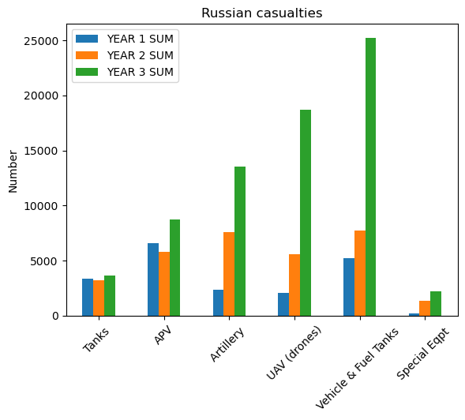

| ITEM | YEAR 1 SUM | YEAR 2 SUM | YEAR 3 SUM |
| --- | --- | --- | --- |
| Tanks | 3,350 | 3,176 | 3,635 |
| APV | 6,593 | 5,817 | 8,724 |
| Artillery | 2,352 | 7,564 | 13,569 |
| UAV (drones) | 2,029 | 5,599 | 18,684 |
| Vehicle & Fuel Tanks | 5,215 | 7,745 | 25,239 |
| Special Eqpt | 228 | 1,347 | 2,182 |

# Russia is not dominant in the air or sea

The next graph shows that in the first year of the war the Russian aircraft, helicoptors and warships were hit hard but that in the following two years those losses have declined dramatically.

The flagship of the Russian Navy's Black Sea Fleet, was attacked and sunk by Ukrainian forces on 14 April 2022. Once again the Ukrainians have proved themselves smarter fighters in this war. Ukraine has deployed sea or boat drones to wipe out Russian ships.

Since year one it has been too risky for Russia to deploy aircraft over or close to the contact line, which accounts for their reduced losses.

American General, Ben Hodges (retired) has repeatedly pointed out that the Russians have never been able to hit even one supply train from Poland. This illustrates how badly they are struggling.

Russia does do a lot of damage to both Ukrainian troops and civilians with their glide bombs which are launched 50km back from the contact line. Ukraine needs long range weapons to combat this.

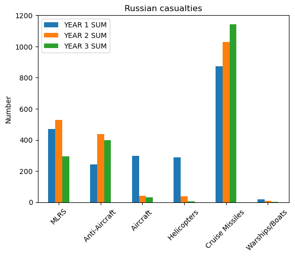

| ITEM | YEAR 1 SUM | YEAR 2 SUM | YEAR 3 SUM |
| --- | --- | --- | --- |
| MLRS | 471 | 528 | 295 |
| Anti-Aircraft | 244 | 438 | 398 |
| Aircraft | 299 | 40 | 32 |
| Helicopters | 287 | 38 | 6 |
| Cruise Missiles | 873 | 1,030 | 1,144 |
| Warships/Boats | 18 | 7 | 3 |

# Concluding comments

The graphs and commentary show that Russia is losing this war. Protracted war favours the Ukrainians.

The Main Stream Media narrative, repeated by Trump, Vance and Musk, that the Russians are relentlessly grinding down the Ukrainians is false.

The Europeans are stepping up and have already increased their supply of munitions and other war fighting and victory necessities to Ukraine. A ‘coalition of the willing’ (COW) is now being developed/established with loud promises of more to come AND the individual governments' monies to make good on these commitments now publicly authorised (see the biggest player Germany).

The US, no matter how desirable its positive involvement would be, will not ‘remain’ essential to Ukrainian victory if the US leadership chooses to not continue supporting Ukraine.

The US supply chain will not determine the outcome any more than Russia.

# Resources

These resources identify various analysts. To obtain a more detailed perspective it is recommended to google these authors and listen to their podcasts when available.

- General Ben Hodges https://en.wikipedia.org/wiki/Ben_Hodges
- General Philip Breedlove https://en.wikipedia.org/wiki/Philip_M._Breedlove
- General Mick Ryan https://www.csis.org/people/mick-ryan
- Anders Puck Nielsen https://www.youtube.com/@anderspuck
- Perun https://www.youtube.com/@PerunAU
- Combat Veteran https://www.youtube.com/watch?v=i0tR4Ejd59M
- Jake Bro https://www.youtube.com/channel/UCYHosdETLPp6dpJEsgIUTmw
- Ryan McBeth https://www.youtube.com/@RyanMcBethProgramming
- Military and History https://www.youtube.com/watch?v=_EHX6R2oxKY
- Ukraine The Latest https://podcasts.apple.com/gb/podcast/ukraine-the-latest/id1612424182
- Ukraine News TV https://www.youtube.com/@AutocracyTV
- Kyiv Post https://www.kyivpost.com/videos/49129
- Chuck Pfarrer https://en.wikipedia.org/wiki/Chuck_Pfarrer
- Suchomimus https://www.youtube.com/@suchomimus9921
- Professor Gerdes Explains https://www.youtube.com/@Professor-Gerdes
- Mark Galeotti Bing Videos
- Vlad Vexler https://www.youtube.com/vladvexler
- Andrew Perpetua https://www.youtube.com/@andrewperpetua
- Institute for the study of war. https://www.youtube.com/@UnderstandingWarOrg
- Map https://liveuamap.com/en/2025/14-march-12-drones-have-attacked-military-training-ground
- Weapons lists https://en.wikipedia.org/wiki/List_of_Russo-Ukrainian_War_military_equipment
- War Russian invasion of Ukraine - Wikipedia
- Fortifications https://en.wikipedia.org/wiki/Fortifications_of_the_Russian_invasion_of_Ukraine
- The Iconic Weapons Of The War So Far https://www.youtube.com/watch?v=iWmf3SvPFE0 .
- Military issues https://en.wikipedia.org/wiki/List_of_military_strategies_and_concepts

Graphs are by Bill Kerr based upon the statistics of the Ukrainian armed forces collected over 3 years. Comments by Patrick Muldowney.